# ETC3250/5250 IML Asignment 3 Solution

Kumar Vatsal (32877692)

2023-06-08

```r
library(tidyverse)
library(rpart)
library(kknn)
library(rsample)
library(ranger)
library(xgboost)
library(yardstick)
```

```r
set.seed(32877692)
```

## Preliminary analysis

```r
data <- read_csv(here::here("data32877692.csv"))


data_new <- read_csv(here::here("newrecords32877692.csv"))
```

### Question 1 What is the letter in your data?

[figure not shown]

```r
imagedata_to_plotdata <- function(data = data,
                                  w = 28,
                                  h = 28,
                                  which = sample(1:3414,12))

  {
   data %>%
    mutate(id = 1:n()) %>%
    filter(id %in% which) %>%
    pivot_longer(starts_with("V")) %>%
    mutate(col = rep(rep(1:w, each = h), n_distinct(id)),
           row = rep(rep(1:h, times = w), n_distinct(id)))
}

gfaces <- imagedata_to_plotdata(data) %>%
    ggplot(aes(col, row)) +
    geom_tile(aes(fill = value)) +
    scale_y_reverse() +
    theme_void(base_size = 18) +
    guides(fill = "none") +
    coord_equal()

gfaces
```

The letter in my data is **C**

### Question 2 Plot a random sample of 12 images, like below, of your data with the correct orientation.

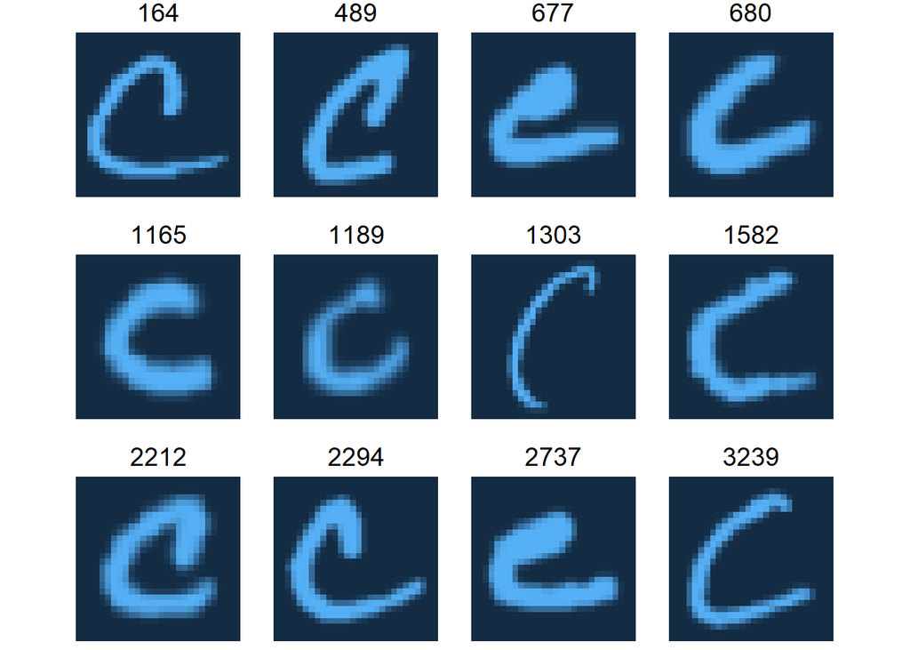

```r
imagedata_to_plotdata <- function(data = data,
                                  w = 28,
                                  h = 28,
                                  which = sample(1:3414,12))

  {
   data %>%
    mutate(id = 1:n()) %>%
    filter(id %in% which) %>%
    pivot_longer(starts_with("V")) %>%
    mutate(col = rep(rep(1:w, each = h), n_distinct(id)),
           row = rep(rep(1:h, times = w), n_distinct(id)))
}

gfaces2 <- imagedata_to_plotdata(data) %>%
    ggplot(aes(col, row)) +
    geom_tile(aes(fill = value)) +
    facet_wrap(~id) +
    scale_y_reverse() +
    theme_void(base_size = 18) +
    guides(fill = "none") +
    coord_equal()

gfaces2
```

### Question 3 Perform a principal component analysis (PCA) on your data. How much variation does the first 5 principal components explain in the data?

```r
data_pca <- prcomp(data)
a <- (data_pca$sdev^2 / sum(data_pca$sdev^2)) %>% head(5)
a
```

```
## [1] 0.16281199 0.13730354 0.09896470 0.06560429 0.05048693
```

- Variation explained by PC1 = 16.28%
- Variation explained by PC2 = 13.73%
- Variation explained by PC3 = 9.89%
- Variation explained by PC4 = 6.56%
- Variation explained by PC5 = 5.04%

```r
cumsum(data_pca$sdev^2 / sum(data_pca$sdev^2)) %>% head(5)
```

```
## [1] 0.1628120 0.3001155 0.3990802 0.4646845 0.5151714
```

Cumulative variation explained by first 5 PCs = 51.51%

### Question 4 Show what aspect of the data the first and second principal component loadings capture like the example plot below.

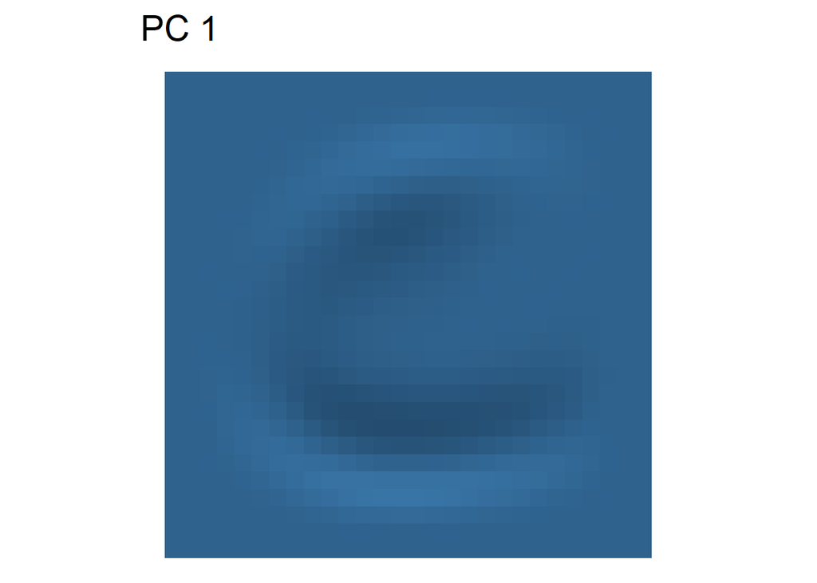

```r
pc_decompose <- function(k) {
  Xnew <- data_pca$x[, k, drop = FALSE] %*% t(data_pca$rotation[, k, drop = FALSE])

  as.data.frame(Xnew) %>%
    imagedata_to_plotdata()
}


gfaces %+% pc_decompose(1) + labs(title = "PC 1")
```

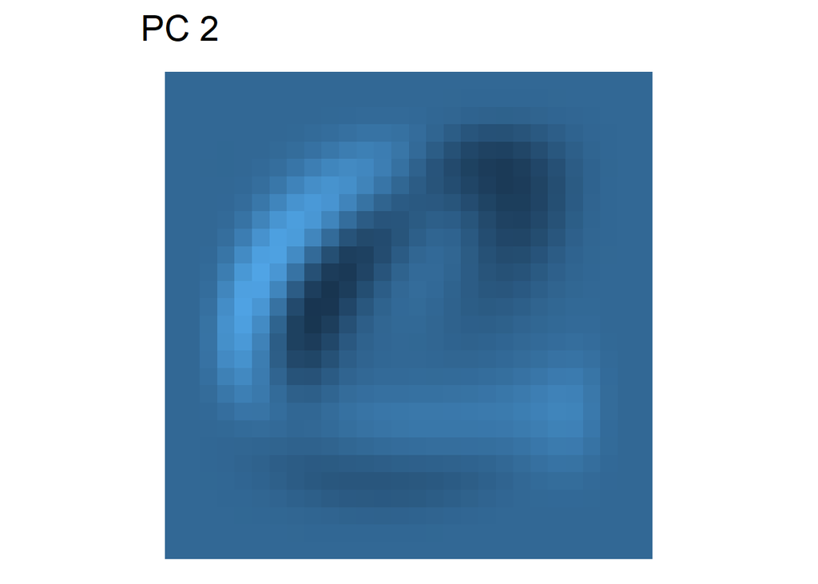

```r
gfaces %+% pc_decompose(2) + labs(title = "PC 2")
```

The first principle component explains a c which is lower case and has a longer bottom part as compared to the top part, its also rotated in anticlockwise direction slightly.

The second principle component shows a c which has a longer top part with the top part coming down.

### Question 5 Using the rotated data from the PCA, perform an agglomerative hierarchical clustering with average linkage.

```r
h_avg <- hclust(dist(data_pca$x), method = "average")
```

### Question 6 Cut the tree from question 5 to 4 clusters. Show how many observations you have per cluster.

```r
cut_avg <- cutree(h_avg, k = 4)
table(cut_avg)
```

```
## cut_avg
##    1    2    3    4
## 3408    2    3    1
```

### Question 7 Show a sample of 10 (or the total number of images in a cluster if less than 10 observations in a cluster) images from each cluster like the plot below. What do you notice about the cluster groups?

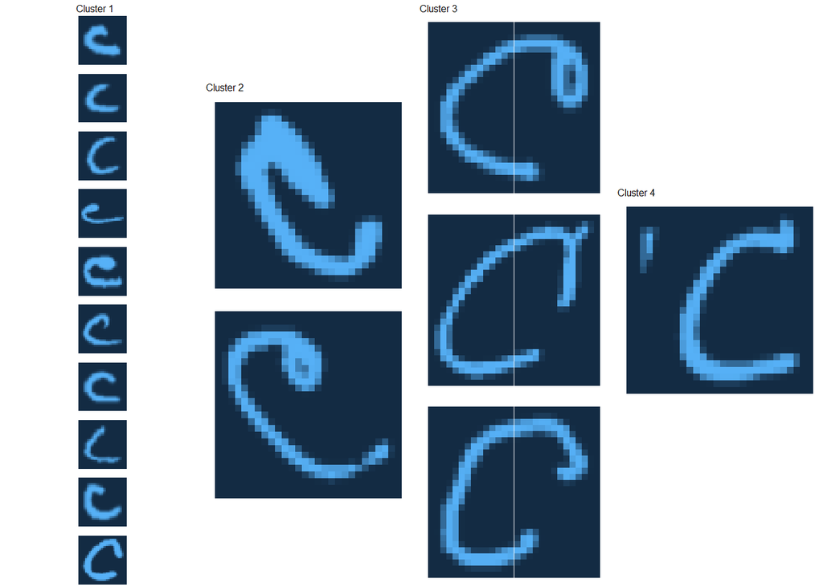

```r
data2 <- cbind(data,cut_avg)  # combining the data with cluster vector.


abc <- data2 %>%              # sampling the data for random samples from each cluster.
  group_by(cut_avg) %>%
  slice_sample(n = 10) %>%
  ungroup()


imagedata_to_plotdata_4 <- function(data = abc,
                                  w = 28,
                                  h = 28)
{
   data %>%
    mutate(id = 1:n()) %>%
    pivot_longer(starts_with("V")) %>%
    mutate(col = rep(rep(1:w, each = h), n_distinct(id)),
           row = rep(rep(1:h, times = w), n_distinct(id)))
}

qwerty <- list(1,2,3,4)

plot_list <- list()


for(i in qwerty){
  plotsabc <- imagedata_to_plotdata_4(abc) %>%
  filter(cut_avg == i) %>%
    ggplot(aes(col, row)) +
    geom_tile(aes(fill = value)) +
    facet_wrap(~id , nrow = 10 ) +
    scale_y_reverse() +
    theme_void(base_size = 5) +
    theme(strip.text.x = element_blank()) +
    guides(fill = "none") +
    coord_equal() +
  ggtitle(paste("Cluster",i))
  plot_list[[i]] <- plotsabc
}


grid_plot <- gridExtra::grid.arrange(grobs = plot_list, ncol = 4)
```

```r
print(grid_plot)
```

- For cluster 1, we can see that Most of C’s that are captured are lower case and are thick in the middle.
- For cluster 2, the C’s captured are tilted towards the top left corner.
- For cluster 3, the C’s captured are tilted toward the top right corner.
- For cluster 4, only one C is captured which appears to be upper case.

## Report

```r
set.seed(2000)
kout <- kmeans(data_pca$x, centers = 3)
table(kout$cluster)
```

```
##
##    1    2    3
## 1222 1092 1100
```

For the clustering method I have used *kmeans*. It is considered one of the best methods. On testing other methods as well, Kmeans comes out as the best as it gives the most sensible clusters with centers = 3. From the above output, we can see that that k means has almost clusterd equal number of observations in each cluster which is a good sign.

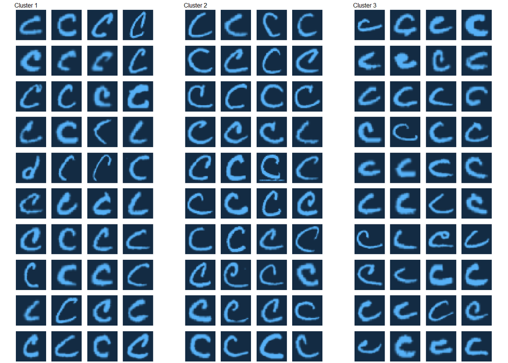

```r
set.seed(32877692)

cluster_number <- factor(kout$cluster)
data3 <- cbind(data,cluster_number)  # combining the data with cluster vector.

abc2 <- data3 %>%              # sampling the data for random samples from each cluster.
  group_by(cluster_number) %>%
  slice_sample(n = 40) %>%
  ungroup()

imagedata_to_plotdata_5 <- function(data = abc2,
                                  w = 28,
                                  h = 28)
{
   data %>%
    mutate(id = 1:n()) %>%
    pivot_longer(starts_with("V")) %>%
    mutate(col = rep(rep(1:w, each = h), n_distinct(id)),
           row = rep(rep(1:h, times = w), n_distinct(id)))
}


qwerty2 <- list(1,2,3)

plot_list2 <- list()


for(i in qwerty2){
  plotsabc2 <- imagedata_to_plotdata_4(abc2) %>%
  filter(cluster_number == i) %>%
    ggplot(aes(col, row)) +
    geom_tile(aes(fill = value)) +
    facet_wrap(~id , nrow = 10 ) +
    scale_y_reverse() +
    theme_void(base_size = 5) +
    theme(strip.text.x = element_blank()) +
    guides(fill = "none") +
    coord_equal() +
  ggtitle(paste("Cluster",i))
  plot_list2[[i]] <- plotsabc2
}


grid_plot2 <- gridExtra::grid.arrange(grobs = plot_list2, ncol = 3)
```

# Explanation of the clusters -

- Cluster 1 : Cluster 1 has a mixture of two types of C’s. The first one are the Upper case ones which generally has thin body and stroke. The lower case c’s have thicker stroke but most of them are straight with some of them having a longer upper part. Also, I notice that in cluster 1, **both ends of the letter c are quite far apart.**
- Cluster 2 : Cluster 2 mostly comprises of *upper case C*. The C’s in cluster two have a **longer upper part with the end of upper part having a line coming down**. The **upper case c also have very thin body.** The lower case c in cluster 2 **also have a line coming down from the upper part of the letter.**. Due to the line, the difference between the two ends of the c’s is lesser.
- Cluster 3 : Cluster 3 majorly comprises of *lower case c’s.* Some of the C’s in this cluster are **rotated in anticlockwise direction.** Almost all of the c’s in this cluster have a **longer lower stroke and have a thick center part.**

# Approach

I firstly divide our original data in training and test set. I already have the clusters from the kmeans. The proportion of training and testing data is 7/10.

Now, I did the PCA on the training data and fit a model using the PCs obtained. Then I multiply the transformation i.e. the rotation matrix from our training data to our testing data. This is done so that we use only the information from our training set and not our testing set. If we directly did PCA on our training data, we are hampering the information. I take first 75 PC’s because they explain almost 95% of our data.

Then, I fit our ML models like, *knn, random-forest, xgboost, decision trees.* I then test these models and found out the accuracy of different models. Then I fit the best model on whole of our original data and perform the similar operations(multiplying the rotation matrix to our test data) on the **new records data(data_new)**. Then I find the predictions for the test set.

```r
set.seed(32877692)

data_split <- initial_split(data3, prop = 0.7)

data_train <- training(data_split)
data_test <- testing(data_split)


data_train_pca <- prcomp(data_train %>% select(-cluster_number))


cluster_train <- (data_train$cluster_number)
cluster_test <- (data_test$cluster_number)


new_x <- as.data.frame(cbind(data_train_pca$x[,1:75],cluster_train)) %>%
  mutate(cluster_train = as.factor(cluster_train))




transformed <-   as.matrix((data_test %>% select(-cluster_number))) %*% data_train_pca$rotation


transformed2 <- as.data.frame(cbind(transformed[,1:75],cluster_test)) %>%
  mutate(cluster_test = as.factor(cluster_test))
```

```r
#rpart
set.seed(32877692)
fit1 <- rpart(cluster_train~., data = new_x, method = "class")

pred_rp_data <- transformed2 %>%
  mutate(pred_clust = predict(fit1, newdata = ., type = "class"))
```

```r
#knn
set.seed(32877692)
knn <- kknn(cluster_train ~ .,
                 train = new_x,
                 test = transformed2,
                 k = 2 ,
                 distance = 2)

pred_knn_data  <- transformed2 %>%
  mutate(pred_clust = knn$fitted.values)
```

```r
#ranger
set.seed(32877692)
class_rf <- ranger(cluster_train ~ .,
                   data = new_x,
                   mtry = floor((ncol(new_x) - 1) / 3),
                   importance = "impurity",
                   num.trees = 500,
                   classification = TRUE)



ranger_pred_data <- transformed2 %>%
  mutate(pred_clust = predict(class_rf, transformed2)$predictions)
```

```r
#xgboost

set.seed(32877692)
class_xgb <- xgboost(data = model.matrix(~ . - cluster_train, data = new_x)[, -1],
                     label = new_x$cluster_train,
                     max.depth = 2,
                     eta = 1,
                     nrounds = 10,
                     objective = "multi:softmax",
                     num_class = 4,
                     verbose = 0)


xgb_pred_data = transformed2 %>%
mutate(pred_clust = predict(class_xgb, model.matrix(~ . - cluster_test, data = .)[, -1])) %>%
  mutate(pred_clust = as.factor(pred_clust))
```

```r
set.seed(32877692)

a <-metrics(pred_rp_data, cluster_test,pred_clust)
b <-metrics(pred_knn_data, cluster_test,pred_clust)
c <- metrics(ranger_pred_data, cluster_test,pred_clust)
d <- metrics(xgb_pred_data, cluster_test,pred_clust)


final <-tibble(
Model_name = c("Rpart","Knn","Random Forest","XgBoost"),
Accuracy = c(a$.estimate[1],b$.estimate[1],c$.estimate[1],d$.estimate[1]),
Kappa = c(a$.estimate[2],b$.estimate[2],c$.estimate[2],d$.estimate[2])
)
final
```

```
## # A tibble: 4 × 3
##   Model_name    Accuracy Kappa
##   <chr>            <dbl> <dbl>
## 1 Rpart            0.748 0.625
## 2 Knn              0.788 0.682
## 3 Random Forest    0.847 0.770
## 4 XgBoost          0.845 0.767
```

Random forest has the highest accuracy but xgboost is very close so I test both and then classify which is the best model.

```r
set.seed(32877692)

train_final <- as.data.frame(cbind(data_pca$x[,1:75],cluster_number)) %>%
  mutate(cluster_number = as.factor(cluster_number))

rota_main <- (data_pca$rotation)

test_x <- as.data.frame(as.matrix(data_new) %*% rota_main)

test_x_final <- test_x[1:75]



# random forest

class_rf2 <- ranger(cluster_number ~ .,
                   data = train_final,
                   mtry = floor((ncol(new_x) - 1) / 3),
                   importance = "impurity",
                   num.trees = 500,
                   classification = TRUE)



ranger_pred_data2 <- test_x_final %>%
  mutate(pred_clust = predict(class_rf2, test_x_final)$predictions)
ranger_pred_data2$pred_clust
```

```
## [1] 2 3 3 3 2
## Levels: 1 2 3
```

```r
# xgboost

class_xgb_final <- xgboost(data = model.matrix(~ . - cluster_number, data = train_final)[, -1],
                     label = train_final$cluster_number,
                     max.depth = 2,
                     eta = 1,
                     nrounds = 10,
                     objective = "multi:softmax",
                     num_class = 4,
                     verbose = 0)


xgb_pred_data2 = test_x_final %>%
mutate(pred_clust = predict(class_xgb_final, model.matrix(~ . , data = .)[, -1]))
xgb_pred_data2$pred_clust
```

```
## [1] 2 3 3 3 2
```

Following are the images that are available in our new records data.

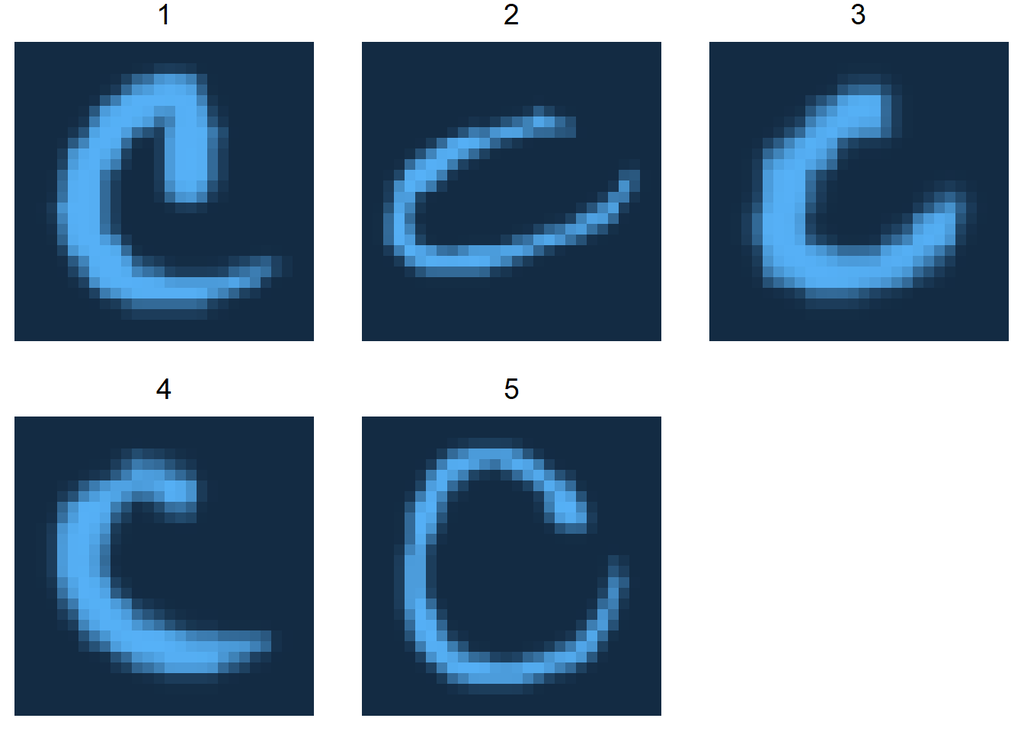

```r
imagedata_to_plotdata <- function(data = data_new,
                                  w = 28,
                                  h = 28)

  {
   data %>%
    mutate(id = 1:n()) %>%
    pivot_longer(starts_with("V")) %>%
    mutate(col = rep(rep(1:w, each = h), n_distinct(id)),
           row = rep(rep(1:h, times = w), n_distinct(id)))
}

gfaces_qw <- imagedata_to_plotdata(data_new) %>%
    ggplot(aes(col, row)) +
    geom_tile(aes(fill = value)) +
    facet_wrap(~id) +
    scale_y_reverse() +
    theme_void(base_size = 18) +
    guides(fill = "none") +
    coord_equal()

gfaces_qw
```

On running both the models on the test data, we find that the predictions made by both the models are same.

- Image 1: The C looks like a uppercase C with a line coming down from the upper part of the letter - *Cluster 2*
- Image 2: The c looks like a lower case one and is rotated in anticlockwise direction - *Cluster 3*
- Image 3: The c is a lower case one with anticlockwise rotation and thick stroke and body - *Cluster 3*
- Image 4: The image appears to be a lower case c with a slightly longer lower part and a slight left/anticlockwise tilt - *Cluster 3*
- Image 5: The image looks like a upper case c with thin strokes and the distance between the upper and lower ends is very less. - *Cluster 2*

# Refferences

- ETC 5250 (Introduction to Machine Learning) lecture slides.
- https://ggplot2.tidyverse.org/articles/faq-faceting.html#:~:text=Set%20the%20strip.,will%20remove%20all%20facet%20labels.
- https://stackoverflow.com/questions/10706753/how-do-i-arrange-a-variable-list-of-plots-using-grid-arrange

# Conclusion

On testing both the models with the highest accuracy, I found out that both the models give similar results, but I will prefer the Ranger approach (model name: class_rf2) as it has a bit higher accuracy.